# Tutorial on Stochastic Block Models

An illustration on antogonistic tree/fungus network

team großBM

2024-02-12

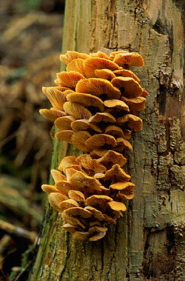

Fungus on tree

## Requirements

This tutorial illustrates the use of block models for the analysis of (ecological) network. Is is mainly based on the vignette of the package `sbm`.

First be sure that you have the `devtools` package

```r
library(devtools)
devtools::install_github('GrossSBM/sbm',ref = 'dev')
```

```r
library(sbm)
```

The packages required for the analysis are `sbm` plus some others for data manipulation and representation:

```r
library(ggplot2)
library(knitr)
```

## Data set: antagonistic tree/fungus interaction network

We consider the fungus-tree interaction network studied by Vacher, Piou, and Desprez-Loustau (2008), available with the package **sbm**:

```r
data("fungusTreeNetwork")
str(fungusTreeNetwork,  max.level = 1)
```

```
#> List of 5
#>  $ tree_names  : Factor w/ 51 levels "Abies alba","Abies grandis",..: 1 2 3 14 42 4 5 6 7 8 ...
#>  $ fungus_names: Factor w/ 154 levels "Amphiporthe leiphaemia",..: 1 2 3 4 5 6 7 8 9 10 ...
#>  $ tree_tree   : num [1:51, 1:51] 0 12 9 3 2 2 0 0 2 7 ...
#>  $ fungus_tree : int [1:154, 1:51] 0 0 0 0 1 1 1 0 0 0 ...
#>  $ covar_tree  :List of 3
```

This data set provides information about $154$ fungi sampled on $51$ tree species. It is a list with the following entries:

- `tree_names` : list of the tree species names
- `fungus_names`: list of the fungus species names
- `tree_tree` : weighted tree-tree interactions (number of common fungal species two tree species host)
- `fungus_tree` : binary fungus-tree interactions
- `covar_tree` : covariates associated to pairs of trees (namely genetic, taxonomic and geographic distances)

We first consider the tree-tree interactions resulting into a Simple Network. Then we consider the bipartite network between trees and fungi.

## Analysis of the tree/tree data

### Tree-tree binary interaction networks

We first consider the binary network where an edge is drawn between two trees when they do share a least one common fungi:

```r
tree_tree_binary <- 1 * (fungusTreeNetwork$tree_tree != 0)
```

The simple function `plotMyMatrix` can be use to represent simple or bipartite SBM:

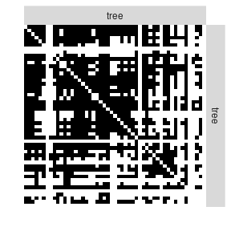

```r
plotMyMatrix(tree_tree_binary, dimLabels = list(row = 'tree', col = 'tree'))
```

We look for some latent structure of the network by adjusting a simple SBM with the function `estimateSimpleSBM`. We assume the our matrix is the realisation of the SBM:
$$\begin{align*}
(Z_i) \text{ i.i.d.} \qquad & Z_i \sim \mathcal{M}(1, \pi) \\
(Y_{ij}) \text{ indep.} \mid (Z_i) \qquad & (Y_{ij} \mid Z_i=k, Z_j
= \ell) \sim \mathcal{B}(\alpha_{k\ell})
\end{align*}$$
and infer this model with `sbm` (used package : `blockmodels`). Note that `simpleSBM` refers to standard networks (w.r.t. bipartite)

```r
mySimpleSBM <- tree_tree_binary %>%
  estimateSimpleSBM("bernoulli",
                    dimLabels ='tree',
                    estimOptions = list(verbosity = 2, plot=FALSE))
```

```
#> -> Estimation for 1 groups
#>
```

```r
-> Computation of eigen decomposition used for initalizations
```

```
#>
#> -> Pass 1
#>     -> With ascending number of groups
#>
```

```r
    -> With descending number of groups
-> Pass 2
```

```
#>     -> With ascending number of groups
#>
```

```r
    -> With descending number of groups
-> Pass 3
```

```
#>     -> With ascending number of groups
#>     -> With descending number of groups
```

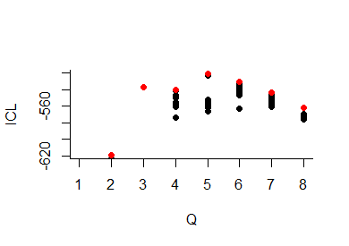

ICL_tree_bin

Once fitted, the user can manipulate the fitted model by accessing the various fields and methods enjoyed by the class `simpleSBMfit`. Most important fields and methods are recalled to the user via the `show` method:

```r
class(mySimpleSBM)
```

```
#> [1] "SimpleSBM_fit" "SimpleSBM"     "SBM"           "R6"
```

For instance,

```r
mySimpleSBM$nbBlocks
```

```
#> [1] 5
```

```r
mySimpleSBM$nbNodes
```

```
#> tree
#>   51
```

```r
mySimpleSBM$nbCovariates
```

```
#> [1] 0
```

The plot method is available as a S3 or R6 method. The default represents the network data reordered according to the memberships estimated in the SBM

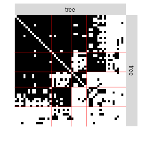

```r
plot(mySimpleSBM, type = "data")
```

One can also plot the expected network which, in case of the Bernoulli model, corresponds to the probability of connection between any pair of nodes in the network.

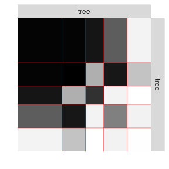

```r
plot(mySimpleSBM, type = "expected", dimLabels = list(row = 'tree', col = 'tree'),estimOptions=list(legend=TRUE))
```

Finally one can plot the mesoscopic view of the network.

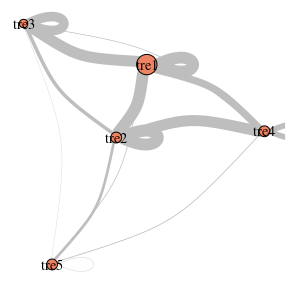

```r
plot(mySimpleSBM, type = "meso",
     dimLabels = list(row = 'tree', col = 'tree'),
     plotOptions = list(edge.width = 1.2))
```

#### About model selection and choice of the number of blocks

During the estimation, a certain range of models are explored corresponding to different number of blocks. By default, the best model in terms of Integrated Classification Likelihood is sent back. IN fact, all the model are stored internally. The user can have a quick glance at them via the `$storedModels` field:

```r
mySimpleSBM$storedModels %>% kable()
```

| indexModel | nbParams | nbBlocks | ICL | loglik |
| --- | --- | --- | --- | --- |
| 1 | 1 | 1 | -883.3334 | -879.7581 |
| 2 | 4 | 2 | -619.0799 | -606.3880 |
| 3 | 8 | 3 | -537.5179 | -512.1339 |
| 4 | 13 | 4 | -540.6318 | -498.9806 |
| 5 | 19 | 5 | -520.6645 | -459.1706 |
| 6 | 26 | 6 | -530.6278 | -445.7159 |
| 7 | 34 | 7 | -544.0191 | -432.1138 |
| 8 | 43 | 8 | -562.1450 | -419.6710 |

We can then what models are competitive in terms of model selection by checking the ICL

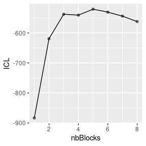

```r
mySimpleSBM$storedModels %>%
  ggplot() +
  aes(x = nbBlocks, y = ICL) + geom_line() + geom_point(alpha = 0.5)
```

The 4-block model could have been a good choice too, in place of the 5-block model. The user can update the current `simpleSBMfit` thanks to the the `setModel` method:

```r
mySimpleSBM$setModel(4)
mySimpleSBM$nbBlocks
```

```
#> [1] 4
```

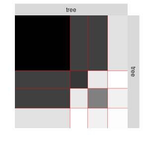

```r
mySimpleSBM$plot(type = 'expected')
```

Going back to th best model

```r
mySimpleSBM$setModel(5)
```

### Analysis of the weighted interaction network

Instead of considering the binary network tree-tree we may consider the weighted network where the link between two trees is the number of fungi they share.

We plot the matrix with function `plotMyMatrix`:

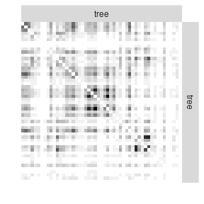

```r
tree_tree <- fungusTreeNetwork$tree_tree
plotMyMatrix(tree_tree, dimLabels = list(row = 'tree', col = 'tree'))
```

Here again, we look for some latent structure of the network by adjusting a simple SBM with the function `estimateSimpleSBM`, considering a Poisson distribution on the edges.

$$\begin{align*}
(Z_i) \text{ i.i.d.} \qquad & Z_i \sim \mathcal{M}(1, \pi) \\
(Y_{ij}) \text{ indep.} \mid (Z_i) \qquad & (Y_{ij} \mid Z_i=k, Z_j
= \ell) \sim \mathcal{P}(\exp(\alpha_{kl})) = \mathcal{P}(\lambda_{kl})
\end{align*}$$

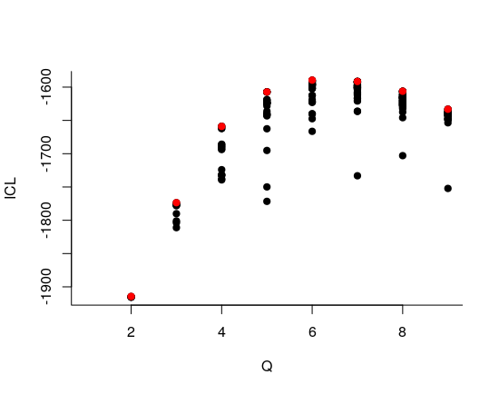

ICL_tree_poisson

```r
mySimpleSBMPoisson <- tree_tree %>%
  estimateSimpleSBM("poisson", directed = FALSE,
                    estimOptions = list(verbosity = 0 , plot = FALSE),
                    dimLabels = c('tree'))
```

Once fitted, the user can manipulate the fitted model by accessing the various fields and methods enjoyed by the class `simpleSBMfit`. Most important fields and methods are recalled to the user via the `show` method:

```r
class(mySimpleSBMPoisson)
```

```
#> [1] "SimpleSBM_fit" "SimpleSBM"     "SBM"           "R6"
```

```r
mySimpleSBMPoisson
```

```
#> Fit of a Simple Stochastic Block Model -- poisson variant
#> =====================================================================
#> Dimension = ( 51 ) - ( 6 ) blocks and no covariate(s).
#> =====================================================================
#> * Useful fields
#>   $nbNodes, $modelName, $dimLabels, $nbBlocks, $nbCovariates, $nbDyads
#>   $blockProp, $connectParam, $covarParam, $covarList, $covarEffect
#>   $expectation, $indMemberships, $memberships
#> * R6 and S3 methods
#>   $rNetwork, $rMemberships, $rEdges, plot, print, coef
#> * Additional fields
#>   $probMemberships, $loglik, $ICL, $storedModels,
#> * Additional methods
#>   predict, fitted, $setModel, $reorder
```

For instance,

```r
mySimpleSBMPoisson$nbBlocks
```

```
#> [1] 6
```

```r
mySimpleSBMPoisson$nbNodes
```

```
#> tree
#>   51
```

```r
mySimpleSBMPoisson$nbCovariates
```

```
#> [1] 0
```

We now plot the matrix reordered according to the memberships estimated in the SBM

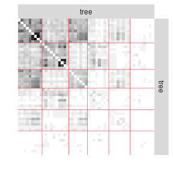

```r
plot(mySimpleSBMPoisson, type = "data")
```

One can also plot the expected network which, in case of the Poisson model, corresponds to the expectation of connection between any pair of nodes in the network.

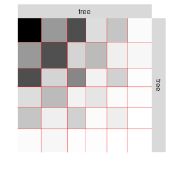

```r
plot(mySimpleSBMPoisson, type = "expected")
```

The same manipulations can be made on the models as before. One can also plot the macroview of the network.

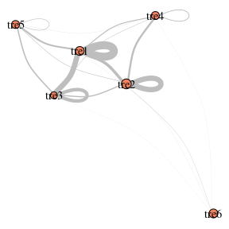

```r
plot(mySimpleSBMPoisson, type = "meso")
```

The composition of the clusters/blocks are given by :

```r
lapply(1:mySimpleSBMPoisson$nbBlocks,
       function(q){fungusTreeNetwork$tree_names[mySimpleSBMPoisson$memberships == q]})
```

```
#> [[1]]
#> [1] Abies alba
#> [2] Abies grandis
#> [3] Cedrus spp (Cedrus atlantica, Cedrus libani)
#> [4] Larix decidua
#> [5] Picea excelsa
#> [6] Pinus nigra laricio
#> [7] Pinus pinaster
#> [8] Pinus sylvestris
#> [9] Pseudotsuga menziesii
#> 51 Levels: Abies alba Abies grandis Abies nordmanniana ... Ulmus spp (Ulmus minor, Ulmus laevis, Ulmus glabra)
#>
#> [[2]]
#>  [1] Large Maples (Acer platanoides, Acer pseudoplatanus)
#>  [2] Fagus silvatica
```

[output cut: 48 more lines]

We are interested in comparing the two clusterings. To do so we use the alluvial flow plots.

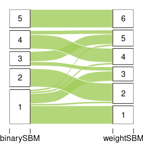

```r
listMemberships <- list(binarySBM = mySimpleSBM$memberships)
listMemberships$weightSBM <- mySimpleSBMPoisson$memberships
P <- plotAlluvial(listMemberships)
```

### Introduction of covariates

We have on each pair of trees 3 covariates, namely the genetic distance, the taxonomic distance and the geographic distance. Each covariate has to be introduced as a matrix: $X^k_{ij}$ corresponds to the value of the $k$-th covariate describing the couple $(i,j)$.

We can also use the `sbm` package to estimate the parameters of the SBM with covariates.

$$\begin{align*}
(Z_i) \text{ i.i.d.} \qquad & Z_i \sim \mathcal{M}(1, \pi) \\
(Y_{ij}) \text{ indep.} \mid (Z_i) \qquad & (Y_{ij} \mid Z_i=k, Z_j
= \ell) \sim \mathcal{P}(\exp(\alpha_{kl} + x_{ij}^\intercal \theta)) =
\mathcal{P}(\lambda_{kl}\exp(x_{ij}^\intercal \theta))
\end{align*}$$

```r
mySimpleSBMCov<- estimateSimpleSBM(
  netMat = as.matrix(tree_tree),
  model = 'poisson',
  directed =FALSE,
  dimLabels =c('tree'),
  covariates  = fungusTreeNetwork$covar_tree,
  estimOptions = list(verbosity = 0))
```

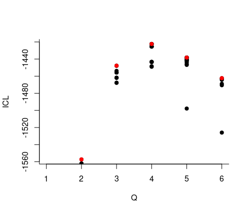

ICL_tree_poisson

- We select the best number of clusters (with respect to the ICL criteria)

```r
mySimpleSBMCov$nbBlocks
```

```
#> [1] 4
```

- We can now extract the parameters of interest, namely ($\lambda$, $\pi$) and the clustering of the nodes.

```r
mySimpleSBMCov$connnectParam
```

```r
mySimpleSBMCov$blockProp
```

```
#> [1] 0.3715916 0.2159544 0.2354117 0.1770424
```

```r
mySimpleSBMCov$memberships
```

```
#>  [1] 1 1 2 1 2 2 4 4 2 1 3 1 1 1 1 2 1 2 3 3 2 1 2 1 3 3 2 1 3 2 3 1 4 1 1 3 1 3
#> [39] 4 1 1 3 2 4 4 1 4 4 3 3 4
```

```r
mySimpleSBMCov$covarParam
```

```
#>            [,1]
#> [1,]  0.1976220
#> [2,] -2.0550285
#> [3,] -0.3582768
```

- The composition of the clusters/blocks are given by:

```r
lapply(1:mySimpleSBMCov$nbBlocks,function(q){fungusTreeNetwork$tree_names[mySimpleSBMCov$memberships == q]})
```

```
#> [[1]]
#>  [1] Abies alba
#>  [2] Abies grandis
#>  [3] Large Maples (Acer platanoides, Acer pseudoplatanus)
#>  [4] Cedrus spp (Cedrus atlantica, Cedrus libani)
#>  [5] Fagus silvatica
#>  [6] Fraxinus spp (Fraxinus angustifolia, Fraxinus excelsior)
#>  [7] Juglans spp (Juglans nigra, Juglans regia)
#>  [8] Larix decidua
#>  [9] Picea excelsa
#> [10] Pinus nigra laricio
#> [11] Pinus pinaster
#> [12] Pinus sylvestris
#> [13] Cultivated Poplars (Populus trichocarpa, P. canescens, P.alba, P.nigra and their cultivated hybrids)
#> [14] Prunus avium
```

[output cut: 47 more lines]

We are interested in comparing the three cluterings. To do so we use the alluvial flow plots

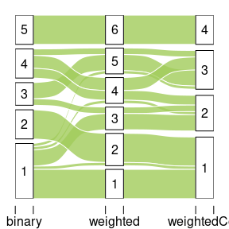

```
#> $plotOptions
#> $plotOptions$curvy
#> [1] 0.3
#>
#> $plotOptions$alpha
#> [1] 0.8
#>
#> $plotOptions$gap.width
#> [1] 0.1
#>
#> $plotOptions$col
#> [1] "darkolivegreen3"
#>
#> $plotOptions$border
#> [1] "white"
#>
#>
#> $tableFreq
#>     binary weighted weightedCov Freq
#> 1        1        1           1    9
#> 6        1        2           1    1
#> 7        2        2           1    9
#> 41       1        3           2    5
#> 43       3        3           2    2
#> 46       1        4           2    1
#> 49       4        4           2    3
#> 79       4        4           3    4
#> 81       1        5           3    1
#> 83       3        5           3    5
#> 84       4        5           3    2
#> 120      5        6           4    9
```

```r
listMemberships <- list(binary = mySimpleSBM$memberships)
listMemberships$weighted <- mySimpleSBMPoisson$memberships
listMemberships$weightedCov <- mySimpleSBMCov$memberships
plotAlluvial(listMemberships)
```

## Analysis of the tree/fungi data

We now analyze the bipartite tree/fungi interactions. The incidence matrix can be plotted with the function

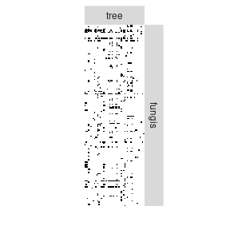

```r
plotMyMatrix(fungusTreeNetwork$fungus_tree, dimLabels=list(row = 'fungis',col = 'tree'))
```

We set the following model:

$$\begin{align*}
(Z^R_i) \text{ i.i.d.} \qquad & Z^R_i \sim \mathcal{M}(1, \pi^R) \\
(Z^C_i) \text{ i.i.d.} \qquad & Z^C_i \sim \mathcal{M}(1, \pi^C)
\\
(Y_{ij}) \text{ indep.} \mid (Z^R_i, Z^C_j) \qquad & (Y_{ij} \mid
Z^R_i=k, Z^C_j = \ell) \sim \mathcal{B}(\alpha_{k\ell})
\end{align*}$$

```r
myBipartiteSBM <- estimateBipartiteSBM(
  netMat = as.matrix(fungusTreeNetwork$fungus_tree),
  model = 'bernoulli',
  dimLabels=c(row = 'fungis',col = 'tree'),
  estimOptions = list(verbosity = 0, plot=FALSE))
```

```r
myBipartiteSBM$nbNodes
```

```
#> fungis   tree
#>    154     51
```

```r
myBipartiteSBM$nbBlocks
```

```
#> fungis   tree
#>      4      4
```

```r
myBipartiteSBM$connectParam
```

```
#> $mean
#>            [,1]        [,2]        [,3]        [,4]
#> [1,] 0.96813478 0.077538579 0.840370657 0.067563355
#> [2,] 0.52055882 0.584398216 0.230893917 0.107930384
#> [3,] 0.32450427 0.003624764 0.098526840 0.005780612
#> [4,] 0.01834547 0.154334411 0.001330278 0.019219920
```

We can now plot the reorganized matrix.

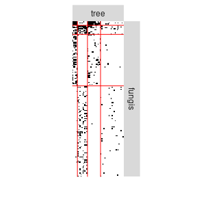

```r
plot(myBipartiteSBM, type = "data")
```

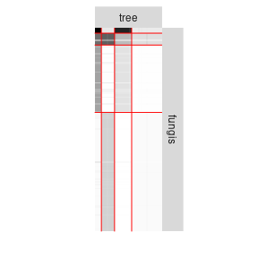

```r
plot(myBipartiteSBM, type = "expected")
```

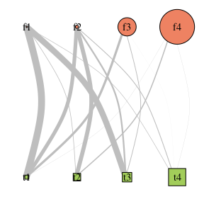

```r
plot(myBipartiteSBM, type = "meso", plotOptions = list(vertex.size=c(0.5,1) , edge.width  = 1))
```

## References

Vacher, Corinne, Dominique Piou, and Marie-Laure Desprez-Loustau. 2008. “Architecture of an Antagonistic Tree/Fungus Network: The Asymmetric Influence of Past Evolutionary History.” *PloS One* 3 (3): e1740.